# Data transformations and intro to experimental designs

Daniel Runcie. Modified from labs designed by Iago Hale, Dario Cantu and Jorge Dubcovsky

## Data transforms

We covered the **log**, **logit**, **inverse**, **sqrt** and **power** transforms in lecture. Follow the R code from lecture 10 to see each of these in action. In lab, you’ll go through an analysis of the logit transformation in detail. Some notes about each transform:

### log transform:

1. You must choose a base ($e$, 2, $10$, etc). Functions are `log`, `log2`, `log10`, `log(x,base=2)`, etc.
   - This affects the interpretation of effect sizes, but not the tests
2. Zeros and negative values are not allowed in your data:

```r
log10(0)
```

```
[1] -Inf
```

```r
log2(3)
```

```
[1] 1.584963
```

```r
log(-3)
```

```
NaNs produced
```

```
[1] NaN
```

```
- If you have zeros, an option is to add a constant to every value. If your values are all reasonably large, adding 1 is OK. If you have values smaller than 1, then `min(y[y>0])/2` is better
```

3. If you choose to de-transform effects, these are multiplicative differences ($\mu_A / \mu$B$). De-transformed means and confidence intervals are **geometric means**

### logit Transform

1. The logit transform converts probabilities into log_e (odds).
2. Treatment effects on the logit scale are interpreted as changes in log-ratios of odds.
3. Data must be converted to the range (0,1). If you data are percentages (20%, 100%), divide by 100. If you data are counts, divide by the total (1/50, 15/50, etc).
4. Ideally, the denominator in your data should be the same (or similar) for each datapoint.
5. If the data are between ~0.3 and 0.7, this transform is usually not needed.
6. Data exactly equal to 0 or 1 will fail the logit transform. The `logit` function squeezes these values into the default range:

```r
library(car)
p = 0.2
logit(p)
```

```
[1] -1.386294
```

```r
log(p/(1-p))  # these are the same
```

```
[1] -1.386294
```

```r
p = 0
logit(p)
```

```
proportions remapped to (0.025, 0.975)
```

```
[1] -3.663562
```

```r
log(p/(1-p))
```

```
[1] -Inf
```

```r
log(0.025/(1-0.025))  # this is what logit(0) returns
```

```
[1] -3.663562
```

### Sqrt

1. Negative values are not allowed:

```r
sqrt(0)
```

```
[1] 0
```

```r
sqrt(-1)
```

```
NaNs produced
```

```
[1] NaN
```

2. Detransformed means have no clear meaning besides squared means of square-root values

### Power Transformation

1. This selects a value $\lambda$ that makes the among-group variances the most homogeneous.
2. The transform itself is
   $$\frac{y^\lambda-1}{\lambda}$$
3. The function `powerTransform` of the `car` package can be used to select $\lambda$, and the function `bcnPower` can be used to apply it to your data.
4. See lecture handout for application.

### Example 1:

The data are the number of lettuce seads germinating in samples of 50 across 24 treatments with three replicates per treatment.

Load the data, inspect and produce a boxplot for each treatment:

```
'data.frame':   72 obs. of  2 variables:
 $ Treatment       : int  1 2 3 4 5 6 7 8 9 10 ...
 $ Germinated_seeds: int  0 0 0 0 2 0 7 11 13 22 ...
```

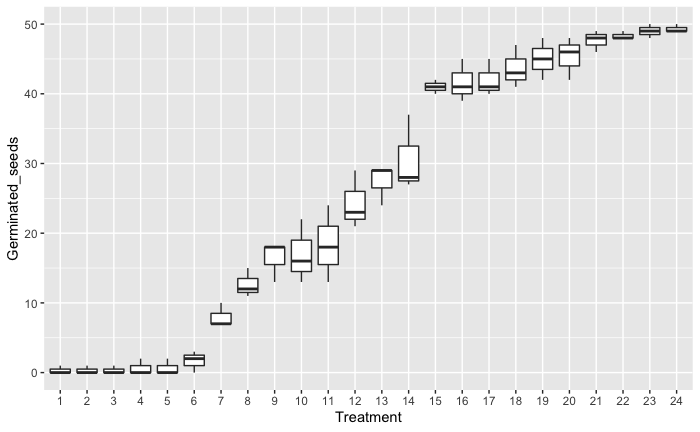

```r
data1$Treatment = factor(data1$Treatment)
ggplot(data1,aes(x=Treatment,y=Germinated_seeds)) + geom_boxplot()
```

The treatments have been ordered by mean for clarity. Note how the spread in each boxplot is greatest for the treatments with mean germination close to 50%.

We can see that again by calculating the variance of each treatment and plotting that directly:

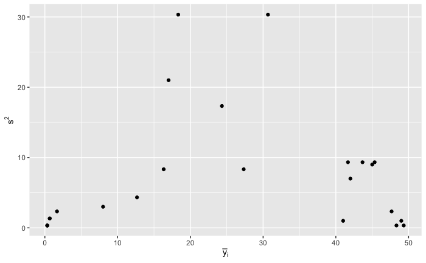

```r
means = aggregate(Germinated_seeds ~ Treatment,data1,FUN=mean)$Germinated_seeds
vars = aggregate(Germinated_seeds ~ Treatment,data1,FUN=var)$Germinated_seeds
ggplot(data.frame(means,vars),aes(x=means,y=vars)) + geom_point() + xlab(expression(bar(y)[i])) + ylab(expression(s^2))
```

Finally, we can see it clearly in the residuals vs fitted values plot that R makes automatically from a linear model (`lm`) fit:

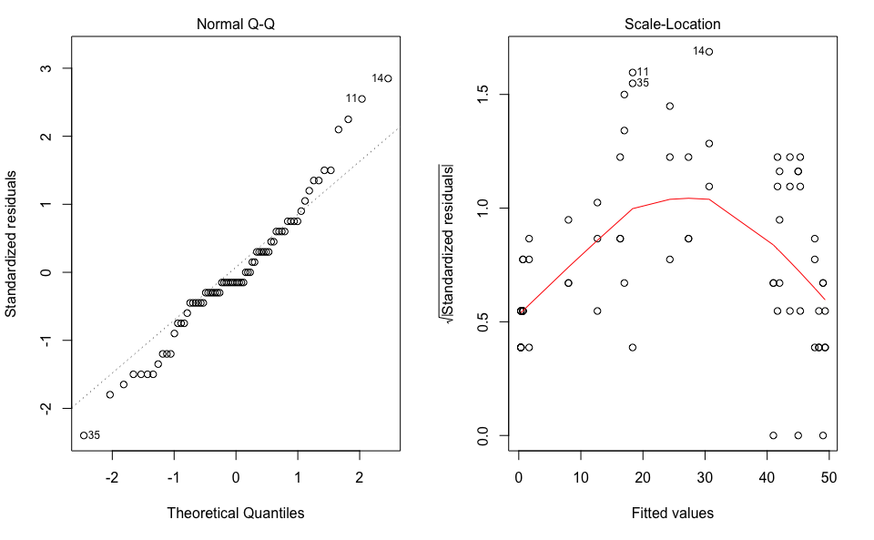

```r
par(mfrow=c(1,2)) # set up plotting device for 2 side-by-side plots
untransformed_model = lm(Germinated_seeds~Treatment,data1)
plot(untransformed_model,which=c(2,3))  # several other plots are available. See ?plot.lm
```

> In the Scale-Location plot, note the hump of higher residuals for intermediate fitted values (treatment means).

> The QQ-plot doesn’t look too bad, but there are a few too many large and small residuals than expected.

Our knowledge of the data, plus these plots suggest that the **logit** transformation will be appropriate. The transformation function looks like this:

```
proportions remapped to (0.025, 0.975)
```

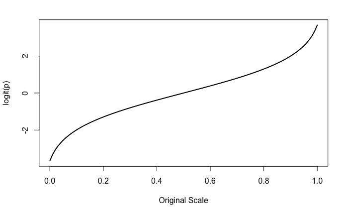

```r
plot(p,logit(p),type='l', xlab = 'Original Scale',lwd=2)
```

You can run the transform like this:

```r
# convert from germination counts to fraction (0-1)
data1$Fraction_germination = data1$Germinated_seeds/50
# apply angular transformation
data1$logit_Y = logit(data1$Fraction_germination)  # see optional parameter adjusts = to change how the function deals with values close to 0 or 1.
```

```
proportions remapped to (0.025, 0.975)
```

Now look at the diagnostic plots. Do you see the difference?

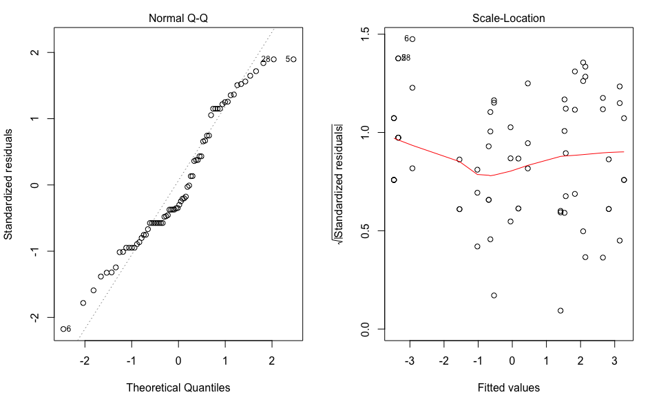

```r
par(mfrow=c(1,2)) # set up plotting device for 2 side-by-side plots
transformed_model = lm(logit_Y~Treatment,data1)
plot(transformed_model,which=c(2,3))  # several other plots are available. See ?plot.lm
```

> The Normal Q-Q plot is a bit worse (there are a couple outliers: ex. pt 5), but is really not bad.

> The Scale-Location plot is much improved

Let’s compare the results of analyses on un-transformed and transformed data:

Use the Tukey procedure with `emmeans` to identify which treatments can be distinguished

First: the raw fraction data:

```r
untransformed_means = emmeans(untransformed_model,specs = 'Treatment')
cld(untransformed_means,alpha = 0.1)
```

```
 Treatment emmean   SE df lower.CL upper.CL .group
 2          0.333 1.57 48    -2.83     3.49  1
 1          0.333 1.57 48    -2.83     3.49  1
 3          0.333 1.57 48    -2.83     3.49  1
 4          0.667 1.57 48    -2.49     3.83  1
 5          0.667 1.57 48    -2.49     3.83  1
 6          1.667 1.57 48    -1.49     4.83  1
 7          8.000 1.57 48     4.84    11.16  12
 8         12.667 1.57 48     9.51    15.83   23
 9         16.333 1.57 48    13.17    19.49    3
 10        17.000 1.57 48    13.84    20.16    34
 11        18.333 1.57 48    15.17    21.49    34
 12        24.333 1.57 48    21.17    27.49     45
 13        27.333 1.57 48    24.17    30.49      5
 14        30.667 1.57 48    27.51    33.83      5
 15        41.000 1.57 48    37.84    44.16       6
 16        41.667 1.57 48    38.51    44.83       67
 17        42.000 1.57 48    38.84    45.16       67
 18        43.667 1.57 48    40.51    46.83       67
 19        45.000 1.57 48    41.84    48.16       67
 20        45.333 1.57 48    42.17    48.49       67
 21        47.667 1.57 48    44.51    50.83       67
 22        48.333 1.57 48    45.17    51.49       67
 23        49.000 1.57 48    45.84    52.16        7
 24        49.333 1.57 48    46.17    52.49        7

Confidence level used: 0.95
P value adjustment: tukey method for comparing a family of 24 estimates
significance level used: alpha = 0.1
```

> We can distinguish the intermediate treatments from each other, but not those with very high or low germination fractions

Now: the transformed data:

```r
transformed_means = emmeans(transformed_model,specs = 'Treatment')
cld(transformed_means,alpha = 0.1)
```

```
 Treatment  emmean   SE df lower.CL upper.CL .group
 2         -3.4686 0.24 48  -3.9505  -2.9867  1
 1         -3.4686 0.24 48  -3.9505  -2.9867  1
 3         -3.4686 0.24 48  -3.9505  -2.9867  1
 4         -3.3422 0.24 48  -3.8241  -2.8603  1
 5         -3.3422 0.24 48  -3.8241  -2.8603  1
 6         -2.9262 0.24 48  -3.4081  -2.4443  1
 7         -1.5471 0.24 48  -2.0290  -1.0652   2
 8         -1.0229 0.24 48  -1.5048  -0.5410   23
 9         -0.6916 0.24 48  -1.1735  -0.2097   234
 10        -0.6421 0.24 48  -1.1240  -0.1602   234
 11        -0.5352 0.24 48  -1.0171  -0.0533   234
 12        -0.0508 0.24 48  -0.5327   0.4311    34
 13         0.1789 0.24 48  -0.3030   0.6608    34
 14         0.4553 0.24 48  -0.0266   0.9372     45
 15         1.4144 0.24 48   0.9325   1.8964      56
 16         1.5299 0.24 48   1.0480   2.0118      567
 17         1.5663 0.24 48   1.0844   2.0482      567
 18         1.8334 0.24 48   1.3515   2.3153       678
 19         2.0763 0.24 48   1.5944   2.5582       6789
 20         2.1408 0.24 48   1.6589   2.6227       6789
 21         2.6548 0.24 48   2.1729   3.1367        789
 22         2.8259 0.24 48   2.3440   3.3078         89
 23         3.1472 0.24 48   2.6653   3.6291          9
 24         3.2736 0.24 48   2.7917   3.7555          9

Confidence level used: 0.95
P value adjustment: tukey method for comparing a family of 24 estimates
significance level used: alpha = 0.1
```

## De-transformation

De-transformation functions can be applied both to treatment means and their confidence intervals.

The de-transformation functions for each transformation are:

### log

```r
y = 10
# natural log:
log_y = log(y)
detransformated_log_y = exp(log_y)
detransformated_log_y
```

```
[1] 10
```

```r
# log-base2:
log2_y = log2(y)
detransformated_log2_y = 2^log2_y
detransformated_log2_y
```

```
[1] 10
```

### logit

```r
y = 0.3
logit_y = logit(y)
detransformed_logit_y = exp(logit_y)/(1+exp(logit_y))
detransformed_logit_y
```

```
[1] 0.3
```

### sqrt

```r
y = 10
sqrt_y = sqrt(y)
detransformed_sqrt_y = sqrt_y^2
detransformed_sqrt_y
```

```
[1] 10
```

### power

The `bcnPowerInverse` function de-transforms data transformed with `bcnPower`. See `?bcnPowerInverse` for details

### Example

We can de-transform the means and confidence invervals like this:

```r
detransformed_means_table = as.data.frame(transformed_means)
detransformed_means_table$emmean = exp(detransformed_means_table$emmean)/(1+exp(detransformed_means_table$emmean))
detransformed_means_table$lower.CL = exp(detransformed_means_table$lower.CL)/(1+exp(detransformed_means_table$lower.CL))
detransformed_means_table$upper.CL = exp(detransformed_means_table$upper.CL)/(1+exp(detransformed_means_table$upper.CL))
detransformed_means_table
```

```
   Treatment     emmean        SE df   lower.CL   upper.CL
1          1 0.03022004 0.2396801 48 0.01888220 0.04803242
2          2 0.03022004 0.2396801 48 0.01888220 0.04803242
3          3 0.03022004 0.2396801 48 0.01888220 0.04803242
4          4 0.03415073 0.2396801 48 0.02137068 0.05415058
5          5 0.03415073 0.2396801 48 0.02137068 0.05415058
6          6 0.05087368 0.2396801 48 0.03204311 0.07985734
7          7 0.17549993 0.2396801 48 0.11618667 0.25631138
8          8 0.26446575 0.2396801 48 0.18171153 0.36796052
9          9 0.33368346 0.2396801 48 0.23622632 0.44777545
10        10 0.34477908 0.2396801 48 0.24527419 0.46004551
11        11 0.36930146 0.2396801 48 0.26558801 0.48667676
12        12 0.48731159 0.2396801 48 0.36989350 0.60614696
13        13 0.54460707 0.2396801 48 0.42482300 0.65944301
14        14 0.61188976 0.2396801 48 0.49333878 0.71852803
15        15 0.80446618 0.2396801 48 0.71758959 0.86947840
16        16 0.82199538 0.2396801 48 0.74039376 0.88203403
17        17 0.82725838 0.2396801 48 0.74732782 0.88576858
18        18 0.86216420 0.2396801 48 0.79437041 0.91013560
19        19 0.88857444 0.2396801 48 0.83122760 0.92812053
20        20 0.89480962 0.2396801 48 0.84009432 0.93231135
21        21 0.93430375 0.2396801 48 0.89778486 0.95838022
22        22 0.94405886 0.2396801 48 0.91245448 0.96469535
23        23 0.95879929 0.2396801 48 0.93494879 0.97414699
24        24 0.96351075 0.2396801 48 0.94222331 0.97714523
```

> Compare these means to the original means on the un-transformed data. How do they compare? Note these are numbers of “Fraction_germation”, and would need to be multiplied by 50 to get #germinated seeds.

### Actually, emmeans can do the de-transformation for you!

If you do the transformation of the response directly in the model itself, Then when you summarize the emmeans table, you can specify `type = 'response'` to have `emmeans` do the de-transformation.

```r
direct_transformed_model = lm(logit(Fraction_germination)~Treatment,data1)
```

```
proportions remapped to (0.025, 0.975)
```

```r
direct_transformed_means = emmeans(direct_transformed_model,specs = 'Treatment')
summary(direct_transformed_means,type='response')
```

```
 Treatment response      SE df lower.CL upper.CL
 1           0.0302 0.00702 48   0.0189   0.0480
 2           0.0302 0.00702 48   0.0189   0.0480
 3           0.0302 0.00702 48   0.0189   0.0480
 4           0.0342 0.00791 48   0.0214   0.0542
 5           0.0342 0.00791 48   0.0214   0.0542
 6           0.0509 0.01157 48   0.0320   0.0799
 7           0.1755 0.03468 48   0.1162   0.2563
 8           0.2645 0.04662 48   0.1817   0.3680
 9           0.3337 0.05329 48   0.2362   0.4478
 10          0.3448 0.05415 48   0.2453   0.4600
 11          0.3693 0.05583 48   0.2656   0.4867
 12          0.4873 0.05988 48   0.3699   0.6061
 13          0.5446 0.05944 48   0.4248   0.6594
 14          0.6119 0.05692 48   0.4933   0.7185
 15          0.8045 0.03770 48   0.7176   0.8695
 16          0.8220 0.03507 48   0.7404   0.8820
 17          0.8273 0.03425 48   0.7473   0.8858
 18          0.8622 0.02848 48   0.7944   0.9101
 19          0.8886 0.02373 48   0.8312   0.9281
 20          0.8948 0.02256 48   0.8401   0.9323
 21          0.9343 0.01471 48   0.8978   0.9584
 22          0.9441 0.01266 48   0.9125   0.9647
 23          0.9588 0.00947 48   0.9349   0.9741
 24          0.9635 0.00843 48   0.9422   0.9771

Confidence level used: 0.95
Intervals are back-transformed from the logit scale
```